# Practical Machine Learning Project: HUMAN ACTIVITY RECOGNITION

Jaime Paz

February 5, 2019

### 1. SUMMARY

Human Activity Recognition - HAR - has emerged as a key research area in the last years and is gaining increasing attention by the pervasive computing research community, especially for the development of context-aware systems. There are many potential applications for HAR, like: elderly monitoring, life log systems for monitoring energy expenditure and for supporting weight-loss programs, and digital assistants for weight lifting exercises.

Using devices such as Jawbone Up, Nike FuelBand, and Fitbit it is now possible to collect a large amount of data about personal activity relatively inexpensively. These type of devices are part of the quantified self movement - a group of enthusiasts who take measurements about themselves regularly to improve their health, to find patterns in their behavior, or because they are tech geeks. One thing that people regularly do is quantify how much of a particular activity they do, but they rarely quantify how well they do it. In this project, your goal will be to use data from accelerometers on the belt, forearm, arm, and dumbell of 6 participants.

Data is available and other information is available in:

http://groupware.les.inf.puc-rio.br/har

### 2. GOAL OF THE PROJECT

The goal of this project is to predict the manner in which the participants of this experiment did the exercise. For this, we should accomplish the next tasks:

##### ** Design a Machine Learning Model for predicting the class (A, B, C, D, E) of the human activity dataset (train)**

##### ** Once the Machine Learning is built, then we need to predict 20 different test classes of a given dataset (test)**

### 3. LOADING PACKAGES AND DATA

```r
library(caret)
library(rattle)
library(rpart.plot)
library(C50)
library(gbm)


##LOADING TRAINING DATASET

hr <- read.csv("pml-training.csv", header = TRUE, na.strings=c("NA", "", "#DIV/0!"))

## LOADING TEST DATASET

testdata <- read.csv("pml-testing.csv", header = TRUE, na.strings=c("NA", "", "#DIV/0!"))
```

#### 4. DATA EXPLORATION (EDA)

Firstly, we start exploring the dataset:

```r
str(hr)
```

```
## 'data.frame':    19622 obs. of  160 variables:
##  $ X                       : int  1 2 3 4 5 6 7 8 9 10 ...
##  $ user_name               : Factor w/ 6 levels "adelmo","carlitos",..: 2 2 2 2 2 2 2 2 2 2 ...
##  $ raw_timestamp_part_1    : int  1323084231 1323084231 1323084231 1323084232 1323084232 1323084232 1323084232 1323084232 1323084232 1323084232 ...
##  $ raw_timestamp_part_2    : int  788290 808298 820366 120339 196328 304277 368296 440390 484323 484434 ...
##  $ cvtd_timestamp          : Factor w/ 20 levels "02/12/2011 13:32",..: 9 9 9 9 9 9 9 9 9 9 ...
##  $ new_window              : Factor w/ 2 levels "no","yes": 1 1 1 1 1 1 1 1 1 1 ...
##  $ num_window              : int  11 11 11 12 12 12 12 12 12 12 ...
##  $ roll_belt               : num  1.41 1.41 1.42 1.48 1.48 1.45 1.42 1.42 1.43 1.45 ...
##  $ pitch_belt              : num  8.07 8.07 8.07 8.05 8.07 8.06 8.09 8.13 8.16 8.17 ...
##  $ yaw_belt                : num  -94.4 -94.4 -94.4 -94.4 -94.4 -94.4 -94.4 -94.4 -94.4 -94.4 ...
##  $ total_accel_belt        : int  3 3 3 3 3 3 3 3 3 3 ...
##  $ kurtosis_roll_belt      : num  NA NA NA NA NA NA NA NA NA NA ...
##  $ kurtosis_picth_belt     : num  NA NA NA NA NA NA NA NA NA NA ...
##  $ kurtosis_yaw_belt       : logi  NA NA NA NA NA NA ...
```

[output cut: 86 more lines]

We should identify the variable which contains the outcome, and dropping those variables without relevant interest. Also, is practical to convert the variable *cvtd_timestamp* into a timestamp object and extracting the year, month, day, weekday, hour and minutes:

```r
table(hr$classe)
```

```
##
##    A    B    C    D    E
## 5580 3797 3422 3216 3607
```

```r
hr$user_name <- NULL
hr$X <- NULL
hr$raw_timestamp_part_1 <- NULL
hr$raw_timestamp_part_2 <- NULL
hr$cvtd_timestamp <- strptime(hr$cvtd_timestamp, "%d/%m/%Y %H:%M")

#extracting years, months, weekdays, hours and minutes
hr$year <- as.numeric(strftime(hr$cvtd_timestamp, "%Y"))
hr$month <- as.numeric(strftime(hr$cvtd_timestamp, "%m"))
hr$weekday <- as.numeric(strftime(hr$cvtd_timestamp, "%d"))
hr$hour <- as.numeric(strftime(hr$cvtd_timestamp, "%H"))
hr$minute <- as.numeric(strftime(hr$cvtd_timestamp, "%M"))
#dropping the original time
hr$cvtd_timestamp <- NULL
```

```r
time <- hr[, c("year", "month", "weekday", "hour", "minute")]
str(time)
```

```
## 'data.frame':    19622 obs. of  5 variables:
##  $ year   : num  2011 2011 2011 2011 2011 ...
##  $ month  : num  12 12 12 12 12 12 12 12 12 12 ...
##  $ weekday: num  5 5 5 5 5 5 5 5 5 5 ...
##  $ hour   : num  11 11 11 11 11 11 11 11 11 11 ...
##  $ minute : num  23 23 23 23 23 23 23 23 23 23 ...
```

```r
#year
table(time$year)
```

```
##
##  2011
## 19622
```

```r
#month
table(time$month)
```

```
##
##    11    12
##  6472 13150
```

```r
#weekday
table(time$weekday)
```

```
##
##    2    5   28   30
## 7428 5722 3070 3402
```

```r
#hour
table(time$hour)
```

```
##
##   11   13   14   17
## 3112 3892 9216 3402
```

```r
#minute
table(time$minute)
```

```
##
##   10   11   12   13   14   15   22   23   24   25   32   33   34   35   56
##  869 1440 1093  833 1498  739  267 1560 2470 1425  177 1321 1375 1019  235
##   57   58   59
## 1380 1364  557
```

Variable *Year* doesn’t seems to any variation across the years. We should investigate later about the others and if they are relevent in our model.

The only issue that we have to overcome, is the variety of imputed **“NAS”** in some variables:

```r
na_count <- function (x) sapply(x, function(y) sum(is.na(y)))
totalnas <- as.data.frame(na_count(hr))
totalnas$names <- rownames(totalnas)
totalnas <- totalnas[which(totalnas$`na_count(hr)` == 0),]
todrop <- as.vector(rownames(totalnas))

#we should keep those variables without NAS
hr <- hr[, todrop]

#backuping data
hrdata <- hr
```

For those variables which will stay in the model, we need to do some diagnosys about those variables which are potentially correlated. For that, we will have two cases: 1) Drop highly correlated variables (> 0.75) and 2) do not drop variables and see the difference.

```r
correlated1 <- findCorrelation(cor(hrdata[, -c(1, 55, 56) ]), cutoff = .75, verbose = FALSE)

#CASE 1: Highly correlated variables dropped:

hrdata1 <- hrdata[, correlated1]

#CASE 2: Do not drop variables

hrdata2 <- hrdata

length(colnames(hrdata))
```

```
## [1] 60
```

```r
length(colnames(hrdata1))
```

```
## [1] 22
```

```r
nearzero1 <- nearZeroVar(hrdata1)
nearzero2 <- nearZeroVar(hrdata2)

#covariates with zero variance in case 1

print(nearzero1)
```

```
## integer(0)
```

```r
#covariates with zero variance in case 2
print(nearzero2)
```

```
## [1]  1 56
```

```r
colnames(hrdata2[,c(1, 56)])
```

```
## [1] "new_window" "year"
```

Variables “new window” and “year” of model two, seem to be having issues with zero variance, so they might be not good predictors.

```r
#returning classes variables for case 1 and 2

hrdata1$classe <- hrdata$classe
hrdata2$classe <- hrdata$classe

#drop variables "new window" and "year" from case 2

hrdata2$new_window <- NULL
hrdata2$year <- NULL

colnames(hrdata1)
```

```
##  [1] "accel_belt_y"         "num_window"           "classe"
##  [4] "accel_arm_x"          "accel_belt_x"         "yaw_belt"
##  [7] "accel_dumbbell_y"     "accel_dumbbell_x"     "gyros_belt_z"
## [10] "roll_belt"            "accel_dumbbell_z"     "gyros_dumbbell_z"
## [13] "magnet_dumbbell_x"    "gyros_arm_z"          "accel_arm_y"
## [16] "magnet_arm_x"         "magnet_belt_y"        "accel_forearm_x"
## [19] "total_accel_dumbbell" "gyros_forearm_x"      "gyros_dumbbell_y"
## [22] "total_accel_arm"
```

Inspecting variable distributions:

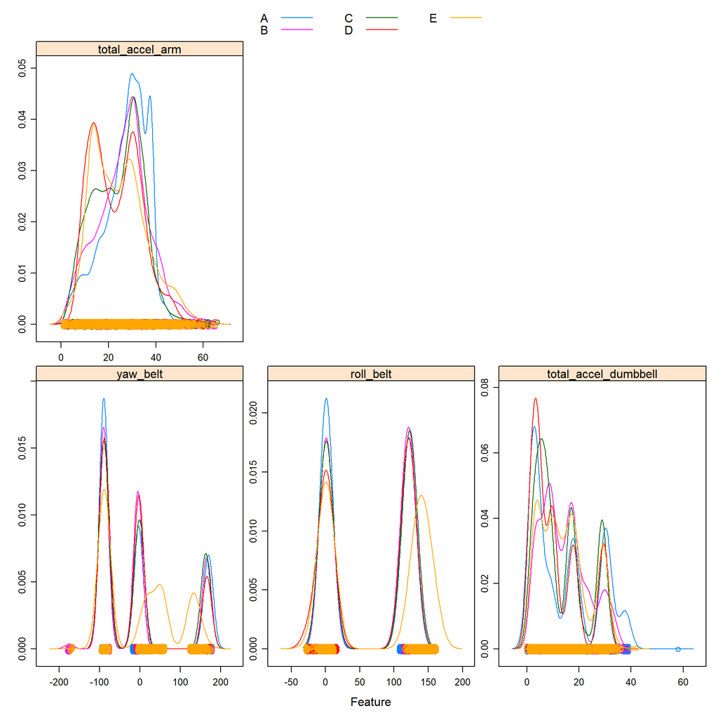

```r
featurePlot(x=hrdata1[,c(6,10,19,22)],
            y=hrdata1$classe,
            plot="density",
            scales=list(x=list(relation="free"),
                        y=list(relation="free")),
            auto.key=list(columns=3), layout=c(3,2))
```

We might expect that variables should be good predictors using the *classe* variables.

#### 5. PREPARING TRAINING DATA

First, we will divide the TRAINING SET into two pieces: one for training the model and other for testing the model with known data. *Obsevation: this is not the TEST set given at the beginning. Is a subset of the “train” data itself*

We will use Cross-Validation for creating two sets (70% for training and 30% for testing set) of data directly from the TRAIN SET:

```r
#case 1

ind = sample(2, nrow(hrdata1), replace = TRUE, prob=c(0.7, 0.3))
hrdatatrain1 = hrdata1[ind == 1,]
hrdatatest1 = hrdata1[ind == 2,]

#case 2

ind = sample(2, nrow(hrdata2), replace = TRUE, prob=c(0.7, 0.3))
hrdatatrain2 = hrdata2[ind == 1,]
hrdatatest2 = hrdata2[ind == 2,]

#creating folds for case 1 and 2

k_10_fold = trainControl(method="repeatedcv", number=10, repeats=3)
```

#### 6. BUILDING A DECISION TREE MODEL

First, we will try to build up a machine learning model using a Decision Tree for both cases:

```r
tree_fit1 <- train(factor(classe) ~., data = hrdatatrain1, method = "rpart",
                   trControl = k_10_fold)

tree_fit2 <- train(factor(classe) ~., data = hrdatatrain2, method = "rpart",
                   trControl = k_10_fold)
```

**CASE 1 MODEL**

```r
print(tree_fit1)
```

```
## CART
##
## 13704 samples
##    21 predictor
##     5 classes: 'A', 'B', 'C', 'D', 'E'
##
## No pre-processing
## Resampling: Cross-Validated (10 fold, repeated 3 times)
## Summary of sample sizes: 12334, 12333, 12334, 12334, 12334, 12335, ...
## Resampling results across tuning parameters:
##
##   cp          Accuracy   Kappa
##   0.02662061  0.5005307  0.36492389
##   0.03195489  0.4482753  0.27432739
##   0.11776062  0.3196807  0.05733549
##
## Accuracy was used to select the optimal model using the largest value.
## The final value used for the model was cp = 0.02662061.
```

```r
print(tree_fit2)
```

```
## CART
##
## 13762 samples
##    57 predictor
##     5 classes: 'A', 'B', 'C', 'D', 'E'
##
## No pre-processing
## Resampling: Cross-Validated (10 fold, repeated 3 times)
## Summary of sample sizes: 12387, 12384, 12385, 12385, 12386, 12386, ...
## Resampling results across tuning parameters:
##
##   cp          Accuracy   Kappa
##   0.03579396  0.5942636  0.48416356
##   0.04235111  0.4978336  0.33839031
##   0.11478402  0.3250237  0.06328475
##
## Accuracy was used to select the optimal model using the largest value.
## The final value used for the model was cp = 0.03579396.
```

#### 7. DECISION TREE - MODEL EVALUATION

Having both models, we will assess both models and checking the **accuracy:**

**CASE 1**

```r
#TRAINING SET

pred_treetrain1 <-predict(tree_fit1, newdata=hrdatatrain1)
t1 <- confusionMatrix(data=pred_treetrain1, hrdatatrain1$classe)
t1$table
```

```
##           Reference
## Prediction    A    B    C    D    E
##          A 2479  433  489  209  115
##          B  399 1378  341  949  496
##          C  976  873 1544 1015  351
##          D    0    0    0    0    0
##          E    8    0    0   98 1551
```

```r
t1$overall
```

```
##       Accuracy          Kappa  AccuracyLower  AccuracyUpper   AccuracyNull
##      0.5072971      0.3764388      0.4988894      0.5157018      0.2818155
## AccuracyPValue  McnemarPValue
##      0.0000000      0.0000000
```

```r
#TESTING SET

pred_treetest1 <-predict(tree_fit1, newdata=hrdatatest1)
t2 <-  confusionMatrix(data=pred_treetest1, hrdatatest1$classe)

t2$table
```

```
##           Reference
## Prediction    A    B    C    D    E
##          A 1062  195  224   82   54
##          B  192  557  151  416  257
##          C  458  361  673  399  165
##          D    0    0    0    0    0
##          E    6    0    0   48  618
```

```r
t2$overall
```

```
##       Accuracy          Kappa  AccuracyLower  AccuracyUpper   AccuracyNull
##   4.917202e-01   3.551199e-01   4.789053e-01   5.045432e-01   2.903008e-01
## AccuracyPValue  McnemarPValue
##  2.076165e-232   0.000000e+00
```

**CASE 2**

```r
#TRAINING SET

pred_treetrain2 <-predict(tree_fit2, newdata=hrdatatrain2)
t3 <- confusionMatrix(data=pred_treetrain2, hrdatatrain2$classe)

t3$table
```

```
##           Reference
## Prediction    A    B    C    D    E
##          A 3424  626  340  346   94
##          B   58  900   82  398  196
##          C  406 1097 1987 1410  731
##          D    0    0    0    0    0
##          E   12    0    0  100 1555
```

```r
t3$overall
```

```
##       Accuracy          Kappa  AccuracyLower  AccuracyUpper   AccuracyNull
##      0.5715739      0.4532677      0.5632555      0.5798620      0.2833890
## AccuracyPValue  McnemarPValue
##      0.0000000      0.0000000
```

```r
#TESTING SET

pred_treetest2 <-predict(tree_fit2, newdata=hrdatatest2)
t4 <- confusionMatrix(data=pred_treetest2, hrdatatest2$classe)

t4$table
```

```
##           Reference
## Prediction    A    B    C    D    E
##          A 1489  298  177  181   41
##          B   23  386   26  170   79
##          C  166  490  810  565  262
##          D    0    0    0    0    0
##          E    2    0    0   46  649
```

```r
t4$overall
```

```
##       Accuracy          Kappa  AccuracyLower  AccuracyUpper   AccuracyNull
##      0.5689420      0.4481403      0.5561455      0.5816698      0.2866894
## AccuracyPValue  McnemarPValue
##      0.0000000      0.0000000
```

CHECKING FOR VARIABLE IMPORTANCE:

```r
importance = varImp(tree_fit1, scale=FALSE)
importance
```

```
## rpart variable importance
##
##   only 20 most important variables shown (out of 21)
##
##                      Overall
## roll_belt             1495.7
## magnet_dumbbell_x     1110.2
## num_window            1100.7
## magnet_arm_x           821.2
## accel_arm_x            803.1
## magnet_belt_y          609.6
## accel_forearm_x        583.6
## gyros_belt_z           567.4
## accel_dumbbell_y       562.0
## gyros_dumbbell_y       370.0
## yaw_belt               331.2
## accel_dumbbell_x       286.3
## total_accel_dumbbell   155.7
## accel_belt_y             0.0
## gyros_arm_z              0.0
## total_accel_arm          0.0
## accel_arm_y              0.0
## gyros_forearm_x          0.0
## gyros_dumbbell_z         0.0
## accel_dumbbell_z         0.0
```

We still can see some variables that don’t add much value to the model. We proceed to drop those variables

```r
importance_df <- as.data.frame(varImp(tree_fit1, scale=FALSE)$importance)
variables_imp <- rownames(subset(importance_df, importance_df$Overall >= 160))

#fitting the model again:

tree_fit1i <- train(factor(classe) ~ accel_arm_x + accel_dumbbell_x +
                          accel_dumbbell_y + accel_forearm_x + gyros_belt_z +
                          gyros_dumbbell_y + magnet_arm_x + magnet_belt_y +
                          magnet_dumbbell_x + num_window + roll_belt +
                          total_accel_dumbbell + yaw_belt  , data =
                          hrdatatrain1, method = "rpart",
                          trControl = k_10_fold)

pred_treetrain1 <-predict(tree_fit1i, newdata=hrdatatrain1)
confusionMatrix(data=pred_treetrain1, hrdatatrain1$classe)
```

```
## Confusion Matrix and Statistics
##
##           Reference
## Prediction    A    B    C    D    E
##          A 2479  433  489  209  115
##          B  399 1378  341  949  496
##          C  976  873 1544 1015  351
##          D    0    0    0    0    0
##          E    8    0    0   98 1551
##
## Overall Statistics
##
##                Accuracy : 0.5073
##                  95% CI : (0.4989, 0.5157)
##     No Information Rate : 0.2818
##     P-Value [Acc > NIR] : < 2.2e-16
##
##                   Kappa : 0.3764
##  Mcnemar's Test P-Value : < 2.2e-16
##
## Statistics by Class:
##
##                      Class: A Class: B Class: C Class: D Class: E
## Sensitivity            0.6419   0.5134   0.6504   0.0000   0.6172
## Specificity            0.8734   0.8017   0.7162   1.0000   0.9905
## Pos Pred Value         0.6655   0.3868   0.3244      NaN   0.9360
## Neg Pred Value         0.8614   0.8712   0.9072   0.8343   0.9201
## Prevalence             0.2818   0.1959   0.1732   0.1657   0.1834
## Detection Rate         0.1809   0.1006   0.1127   0.0000   0.1132
## Detection Prevalence   0.2718   0.2600   0.3473   0.0000   0.1209
## Balanced Accuracy      0.7576   0.6576   0.6833   0.5000   0.8039
```

```r
pred_treetest2 <-predict(tree_fit1i, newdata=hrdatatest2)
confusionMatrix(data=pred_treetest2, hrdatatest2$classe)
```

```
## Confusion Matrix and Statistics
##
##           Reference
## Prediction    A    B    C    D    E
##          A 1054  174  211   89   51
##          B  177  602  167  418  201
##          C  447  398  635  409  147
##          D    0    0    0    0    0
##          E    2    0    0   46  632
##
## Overall Statistics
##
##                Accuracy : 0.4988
##                  95% CI : (0.4859, 0.5117)
##     No Information Rate : 0.2867
##     P-Value [Acc > NIR] : < 2.2e-16
##
##                   Kappa : 0.3646
##  Mcnemar's Test P-Value : < 2.2e-16
##
## Statistics by Class:
##
##                      Class: A Class: B Class: C Class: D Class: E
## Sensitivity            0.6274   0.5128   0.6269   0.0000   0.6130
## Specificity            0.8744   0.7945   0.7110   1.0000   0.9901
## Pos Pred Value         0.6675   0.3847   0.3119      NaN   0.9294
## Neg Pred Value         0.8538   0.8668   0.9012   0.8358   0.9230
## Prevalence             0.2867   0.2003   0.1729   0.1642   0.1759
## Detection Rate         0.1799   0.1027   0.1084   0.0000   0.1078
## Detection Prevalence   0.2695   0.2671   0.3474   0.0000   0.1160
## Balanced Accuracy      0.7509   0.6536   0.6689   0.5000   0.8015
```

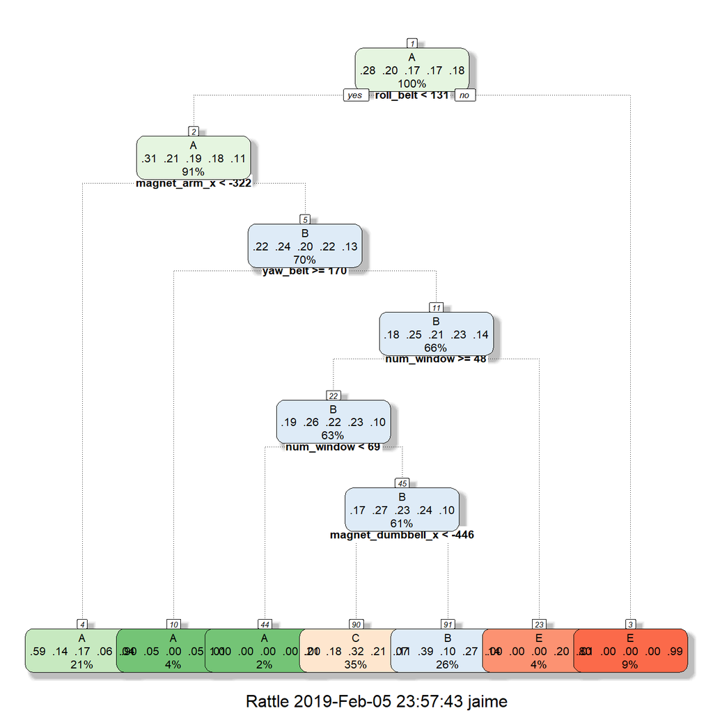

```r
fancyRpartPlot(tree_fit1i$finalModel, cex = 0.65)
```

#### 8. DECISION TREE - MODEL IMPROVEMENT

```r
#include 22 variables of CASE 1:

features <- as.vector(colnames(hrdatatrain1[,c(-3)]))

fit.c50 <-C5.0(hrdatatrain1[, features], hrdatatrain1[, "classe"],
                 control =C5.0Control(CF =0.01, minCases =4))

pred_treebagtrain1 <- predict(fit.c50, newdata=hrdatatrain1)
t5 <- confusionMatrix(data=pred_treebagtrain1, hrdatatrain1$classe)
t5$table
```

```
##           Reference
## Prediction    A    B    C    D    E
##          A 3795   21   17    9   10
##          B   24 2598   26    9   14
##          C    9   34 2316   26    6
##          D   10   24    6 2214   12
##          E   24    7    9   13 2471
```

```r
t5$overall
```

```
##       Accuracy          Kappa  AccuracyLower  AccuracyUpper   AccuracyNull
##   0.9773788675   0.9714094768   0.9747491325   0.9798030887   0.2818155283
## AccuracyPValue  McnemarPValue
##   0.0000000000   0.0004262537
```

```r
pred_treebagtest1 <-predict(fit.c50, newdata=hrdatatest1)

t6 <- confusionMatrix(data=pred_treetest1, hrdatatest1$classe)
t6$table
```

```
##           Reference
## Prediction    A    B    C    D    E
##          A 1062  195  224   82   54
##          B  192  557  151  416  257
##          C  458  361  673  399  165
##          D    0    0    0    0    0
##          E    6    0    0   48  618
```

```r
t6$overall
```

```
##       Accuracy          Kappa  AccuracyLower  AccuracyUpper   AccuracyNull
##   4.917202e-01   3.551199e-01   4.789053e-01   5.045432e-01   2.903008e-01
## AccuracyPValue  McnemarPValue
##  2.076165e-232   0.000000e+00
```

#### 9. RANDOM FOREST - MODEL IMPROVEMENT

```r
rforest.fit <- train(factor(classe) ~.,
                   data = hrdatatrain1,
                   method = "parRF",
                   ntree = 10,
                   trControl=k_10_fold)
pred_rftrain1 <-predict(rforest.fit , newdata=hrdatatrain1)
t7 <- confusionMatrix(data=pred_rftrain1, hrdatatrain1$classe)
t7$table
```

```
##           Reference
## Prediction    A    B    C    D    E
##          A 3862    0    0    0    0
##          B    0 2684    0    0    0
##          C    0    0 2374    0    0
##          D    0    0    0 2271    0
##          E    0    0    0    0 2513
```

```r
t7$overall
```

```
##       Accuracy          Kappa  AccuracyLower  AccuracyUpper   AccuracyNull
##      1.0000000      1.0000000      0.9997309      1.0000000      0.2818155
## AccuracyPValue  McnemarPValue
##      0.0000000            NaN
```

```r
pred_rftest1 <-predict(rforest.fit , newdata=hrdatatest1)

t8 <- confusionMatrix(data=pred_rftest1, hrdatatest1$classe)

t8$table
```

```
##           Reference
## Prediction    A    B    C    D    E
##          A 1718    3    1    1    0
##          B    0 1107    7    1    2
##          C    0    1 1039    4    2
##          D    0    2    1  938    3
##          E    0    0    0    1 1087
```

```r
t8$overall
```

```
##       Accuracy          Kappa  AccuracyLower  AccuracyUpper   AccuracyNull
##      0.9950997      0.9937910      0.9929699      0.9967158      0.2903008
## AccuracyPValue  McnemarPValue
##      0.0000000            NaN
```

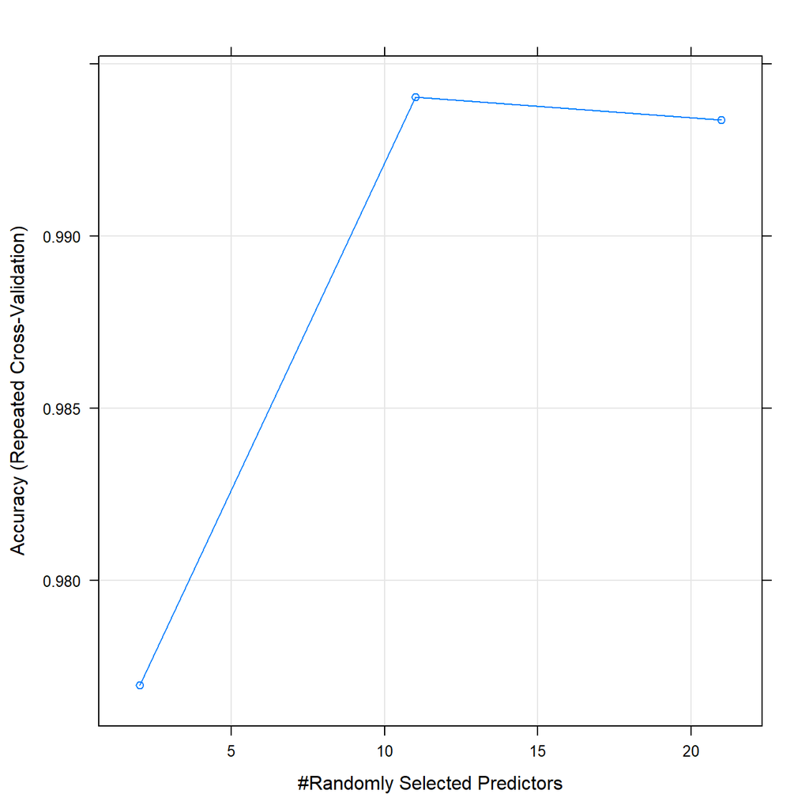

```r
plot(rforest.fit)
```

```r
testcols <- colnames(hrdatatrain1)
testcols <- testcols[-3]
testdata <- testdata[, testcols]
prediction.forest <- predict(rforest.fit , testdata)
rowstest <- rownames(testdata)
data <- as.data.frame(rowstest)
data$predictions <- prediction.forest

data
```

```
##    rowstest predictions
## 1         1           B
## 2         2           A
## 3         3           B
## 4         4           A
## 5         5           A
## 6         6           E
## 7         7           D
## 8         8           C
## 9         9           A
## 10       10           A
## 11       11           B
## 12       12           C
## 13       13           B
## 14       14           A
## 15       15           E
## 16       16           E
## 17       17           A
## 18       18           B
## 19       19           B
## 20       20           B
```